# Bimbo EDA

Alexandru Papiu

June 20, 2016

The Bimbo competition:

### Read and Clean:

Let’s first load the packages and read in the data:

```r
library(data.table)
library(dplyr)
library(ggplot2)
library(knitr)
```

```r
train = fread("/Users/alexpapiu/Documents/Data/Bimbo/train.csv",
              select = c("Semana", "Agencia_ID", "Canal_ID", "Ruta_SAK",
                         "Cliente_ID", "Producto_ID", "Demanda_uni_equil"),
              showProgress = FALSE)


n = 1e6 #number of rows to be subsetted
set.seed(423)
sam = sample(1:nrow(train), n)
train = train[sam]

prod_id = fread("/Users/alexpapiu/Documents/Data/Bimbo/producto_tabla.csv")
town_state = fread("/Users/alexpapiu/Documents/Data/Bimbo/town_state.csv")

train %>% #this takes like 30 seconds.
    left_join(town_state) %>%
    left_join(prod_id) -> train
kable(sample_n(train, 5))
```

| Producto_ID | Agencia_ID | Semana | Canal_ID | Ruta_SAK | Cliente_ID | Demanda_uni_equil | Town | State | NombreProducto |
| --- | --- | --- | --- | --- | --- | --- | --- | --- | --- |
| 43202 | 4051 | 7 | 1 | 1211 | 2332174 | 2 | 2488 JUAREZ | CHIHUAHUA | Mantecadas Vainilla 4p 125g MTA BIM 43202 |
| 972 | 1127 | 9 | 1 | 1422 | 349999 | 1 | 2003 AG. COACALCO | ESTADO DE MÉXICO | Roles Canela 6p 365g BIM 972 |
| 30572 | 2064 | 8 | 11 | 3911 | 4243011 | 4 | 2158 CUERNAVACA CIVAC | MORELOS | Barritas Fresa 67g Prom MTB MLA 30572 |
| 1109 | 1236 | 3 | 1 | 1238 | 4532336 | 2 | 2056 PUEBLA NORTE MARINELA | PUEBLA | Pan Blanco Chico 360g BIM 1109 |
| 1146 | 1117 | 4 | 1 | 1054 | 1040886 | 6 | 2001 AG. ATIZAPAN | ESTADO DE MÉXICO | Pan Integral 675g BIM 1146 |

```r
kable(summary(train))
```

|  | Producto_ID | Agencia_ID | Semana | Canal_ID | Ruta_SAK | Cliente_ID | Demanda_uni_equil | Town | State | NombreProducto |
| --- | --- | --- | --- | --- | --- | --- | --- | --- | --- | --- |
|  | Min. : 41 | Min. : 1110 | Min. :3.000 | Min. : 1.000 | Min. : 1 | Min. : 26 | Min. : 0.000 | Length:1000000 | Length:1000000 | Length:1000000 |
|  | 1st Qu.: 1242 | 1st Qu.: 1312 | 1st Qu.:4.000 | 1st Qu.: 1.000 | 1st Qu.:1161 | 1st Qu.: 355474 | 1st Qu.: 2.000 | Class :character | Class :character | Class :character |
|  | Median :30549 | Median : 1614 | Median :6.000 | Median : 1.000 | Median :1287 | Median : 1190632 | Median : 3.000 | Mode :character | Mode :character | Mode :character |
|  | Mean :20871 | Mean : 2541 | Mean :5.951 | Mean : 1.384 | Mean :2116 | Mean : 1797109 | Mean : 7.235 | NA | NA | NA |
|  | 3rd Qu.:37516 | 3rd Qu.: 2036 | 3rd Qu.:8.000 | 3rd Qu.: 1.000 | 3rd Qu.:2803 | 3rd Qu.: 2368231 | 3rd Qu.: 6.000 | NA | NA | NA |
|  | Max. :49994 | Max. :25759 | Max. :9.000 | Max. :11.000 | Max. :9962 | Max. :99999999 | Max. :4228.000 | NA | NA | NA |

So we have 6 features and the response variable `Demanda_uni_equil` which is continuous.

Really all of our features other than semana (week) are categorical but are encoded as integer ID’s. Let’s change them to characters - this will be helpful for visualizing things. We could have also changed them to factors but a lot of them have many unique values and factors with many levels are unwieldly sometimes. For convenience let’s also change semana to characters.

```r
clean = function(train) {
    train %>%
        mutate(Semana = as.character(Semana),
               Agencia_ID = as.character(Agencia_ID),
               Canal_ID = as.character(Canal_ID),
               Producto_ID = as.character(Producto_ID),
               Ruta_SAK = as.character(Ruta_SAK),
               Cliente_ID = as.character(Cliente_ID)) -> train
    return(train)
}

train = clean(train)
```

Let’s see how many different unique values we have:

```r
sapply(train, function(x)length(unique(x)))
```

```
##       Producto_ID        Agencia_ID            Semana          Canal_ID
##              1341               551                 7                 9
##          Ruta_SAK        Cliente_ID Demanda_uni_equil              Town
##              2268            458392               620               256
##             State    NombreProducto
##                33              1341
```

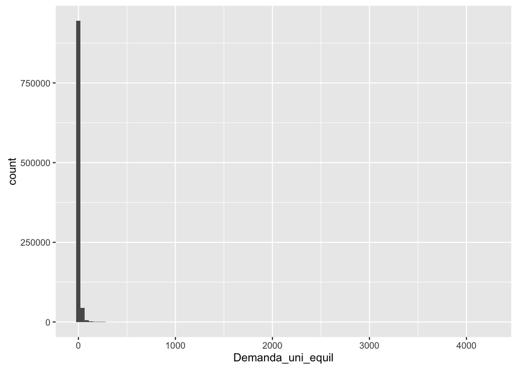

```r
qplot(data = train, x = Demanda_uni_equil, bins = 100)
```

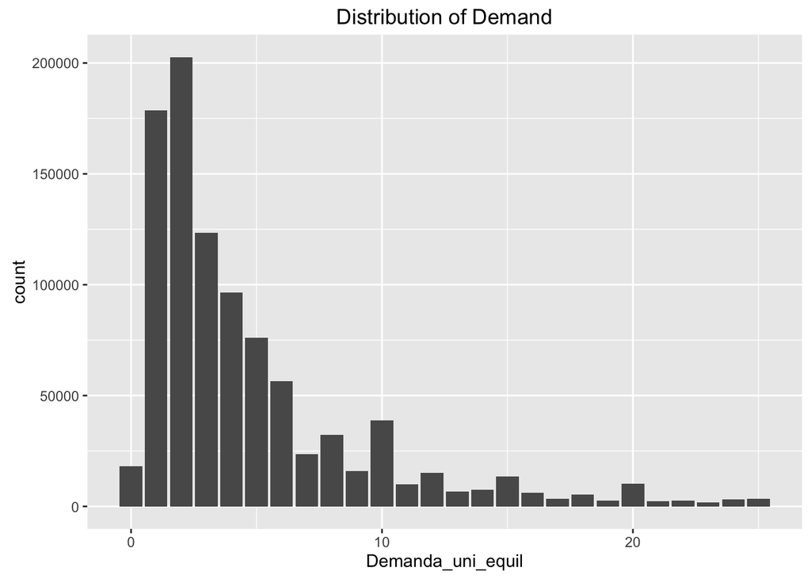

```r
train %>%
    filter(Demanda_uni_equil <= 25) %>%
    ggplot(aes(x = Demanda_uni_equil)) + geom_bar() +
    ggtitle("Distribution of Demand")
```

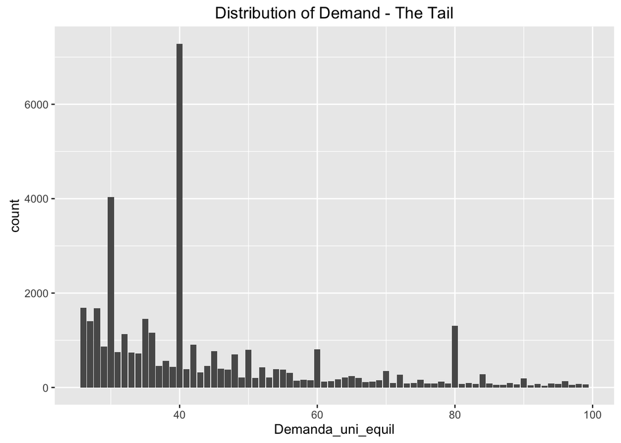

```r
train %>%
    filter(Demanda_uni_equil > 25, Demanda_uni_equil < 100) %>%
    ggplot(aes(x = Demanda_uni_equil)) + geom_bar() +
    ggtitle("Distribution of Demand - The Tail")
```

Hmmm..very interesting - certain “round” values - 40, 60, 80 are much more common as demands.

### Look at the Features:

Let’s first look at semana - the week of the transcation:

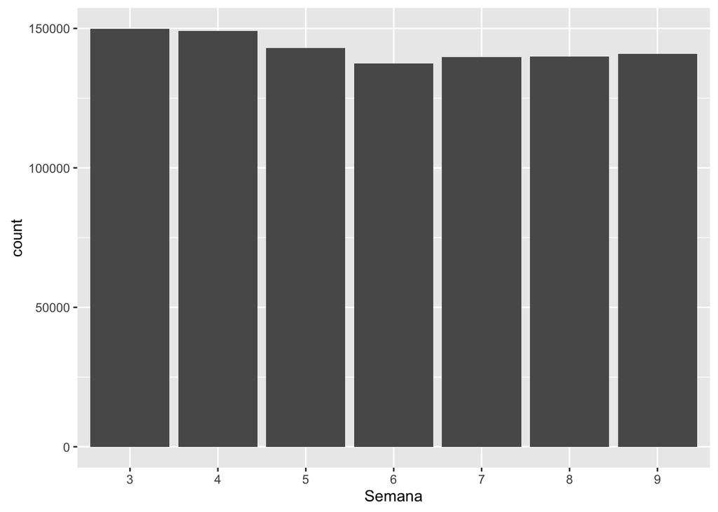

```r
ggplot(train , aes(x = Semana)) + geom_bar()
```

Nothing teribly exciting here, what’s more interesting is to see how the week is related to the demand. The week is a categorical feature while the demand is numerical - what’s the best way to visualize this? Let’s try putting the demand on the x axis and coloring the bars using the categorical features. Since the demand is highly skewed, it’ll help to only look at demands that are smaller. Since we’re probably going to do this with the other variables as well let’s make a function:

```r
plot_it = function(train, feat, tresh = 25) {
    train %>%
        filter(Demanda_uni_equil < tresh) %>%
        ggplot(aes_string(x = "Demanda_uni_equil", fill = feat)) +
        geom_bar(position = "fill") +
        ggtitle(paste("Demand by", feat))
}
```

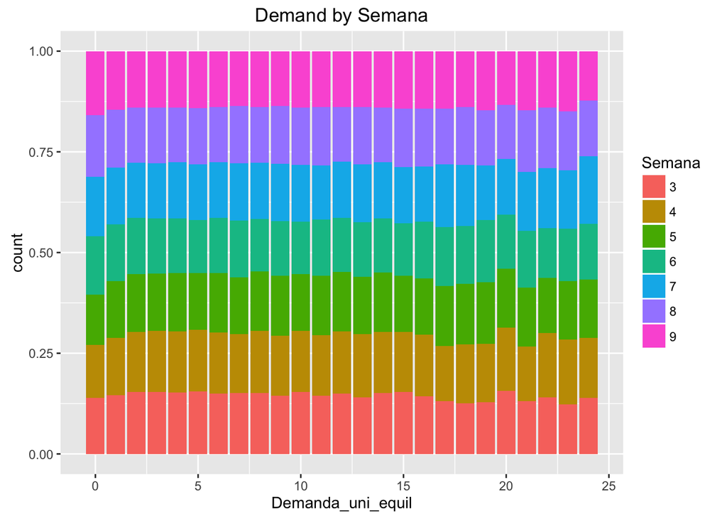

```r
plot_it(train, "Semana")
```

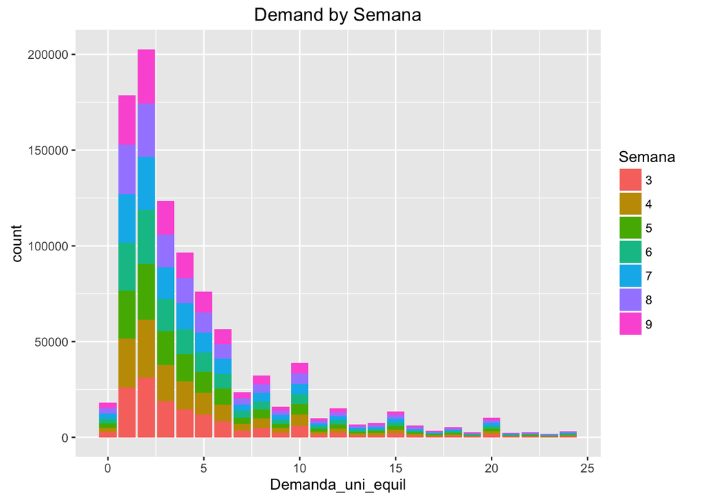

```r
plot_it(train, "Semana") + geom_bar(position = "stack")
```

It doesn’t look like week is going to matter very much.

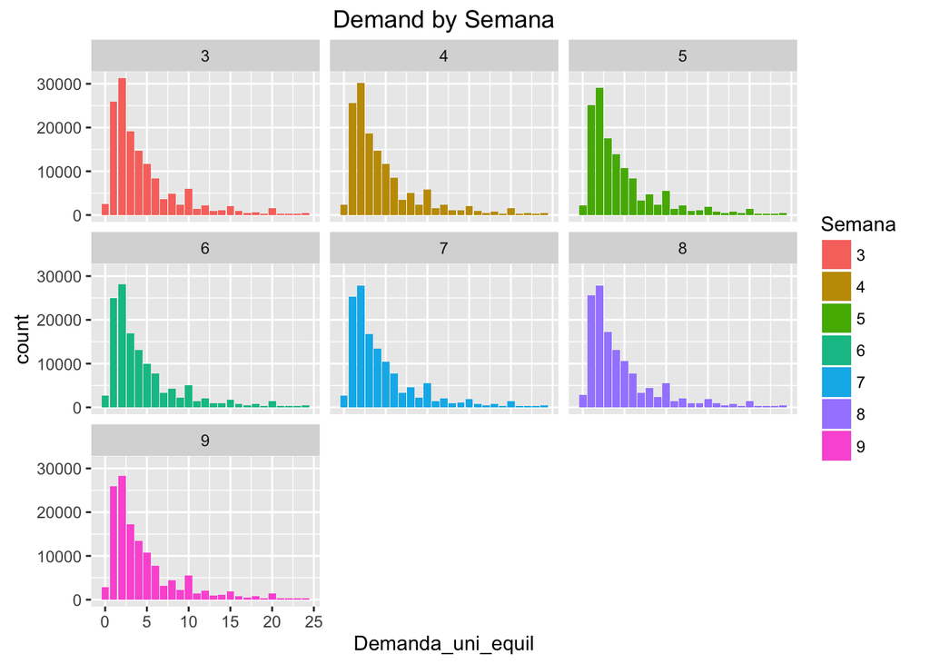

```r
plot_it(train, "Semana") +
    geom_bar(position = "identity") +
    facet_wrap(~ Semana)
```

Looking at Client_ID:

```r
train %>% count(Cliente_ID) %>% arrange(desc(n)) -> clients
top_clients = clients$Cliente_ID[1:21]

kable(head(clients))
```

| Cliente_ID | n |
| --- | --- |
| 653378 | 1727 |
| 653039 | 80 |
| 652850 | 40 |
| 652889 | 24 |
| 1093627 | 24 |
| 625491 | 21 |

Ok let’s look at the top clients:

```r
kable(head(clients))
```

| Cliente_ID | n |
| --- | --- |
| 653378 | 1727 |
| 653039 | 80 |
| 652850 | 40 |
| 652889 | 24 |
| 1093627 | 24 |
| 625491 | 21 |

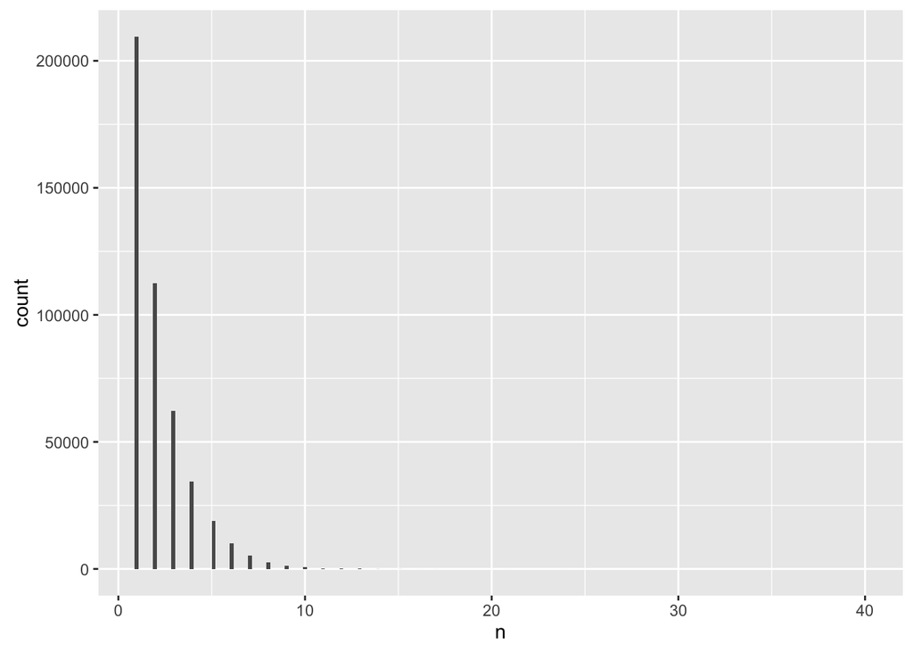

```r
qplot(data = clients[-c(1,2),], n, bins = 200)
```

It looks like there is one client that is a big buyer, let’s look at this cliente first:

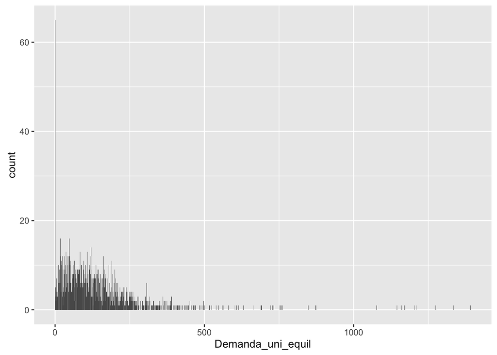

```r
train %>% filter(Cliente_ID == clients$Cliente_ID[1]) -> biggest_client

ggplot(biggest_client, aes(x= Demanda_uni_equil)) + geom_bar()
```

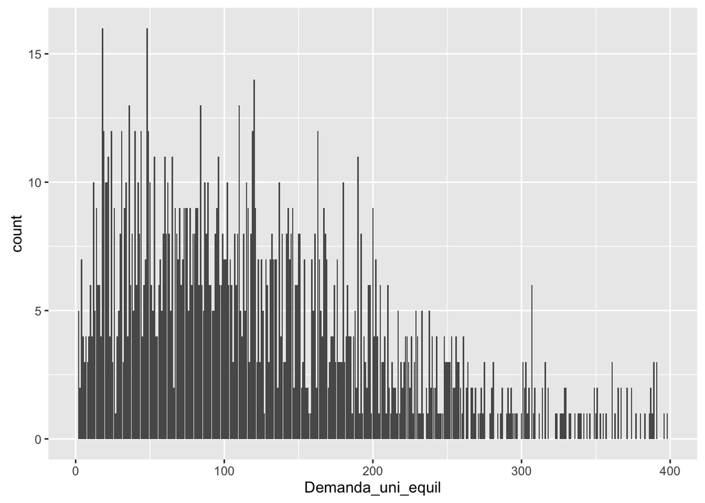

```r
#ok, now let's look at smaller demands only:
biggest_client %>%
    filter(Demanda_uni_equil < 400, Demanda_uni_equil > 1) %>%
    ggplot(aes(x= Demanda_uni_equil)) + geom_bar()
```

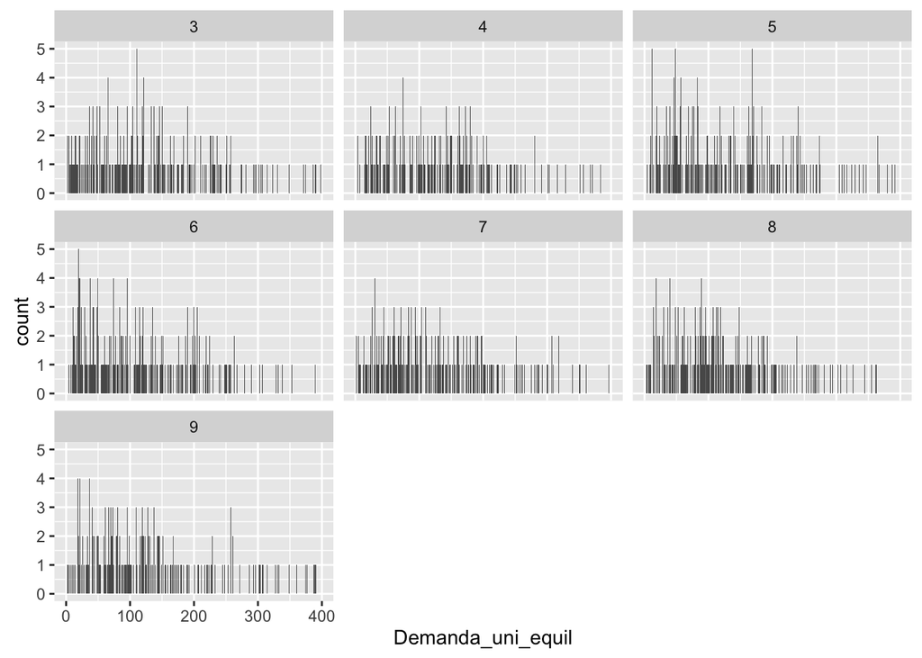

```r
#and by week:
biggest_client %>%
    filter(Demanda_uni_equil < 400, Demanda_uni_equil > 1) %>%
    ggplot(aes(x= Demanda_uni_equil)) +
    geom_bar() +
    facet_wrap( ~ Semana)
```

And by product, unfortunately there are too many product levels so let’s plot the most popular products for this specific client:

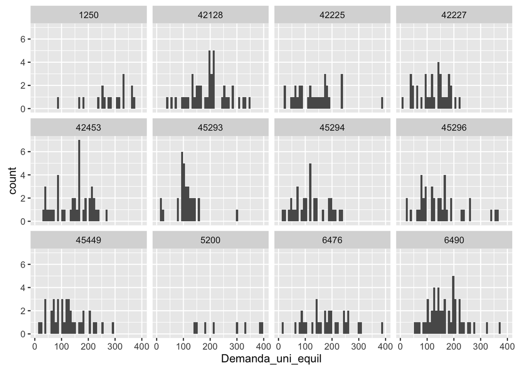

```r
biggest_client %>% count(Producto_ID) %>% arrange(desc(n)) -> products_biggest_client
top_products = products_biggest_client$Producto_ID[1:12]

biggest_client %>%
    filter(Producto_ID %in% top_products) %>%
    filter(Demanda_uni_equil < 400, Demanda_uni_equil > 0) %>%
    ggplot(aes(x= Demanda_uni_equil)) +
    geom_histogram(bins = 50) +
    facet_wrap( ~ Producto_ID)
```

Hmm these distributions are quite different from the oveall distribution of the demand - remember we are looking at the most popular products for the most popular client - so these shouldn’t be too representative of the general population.

Let’s pick another client:

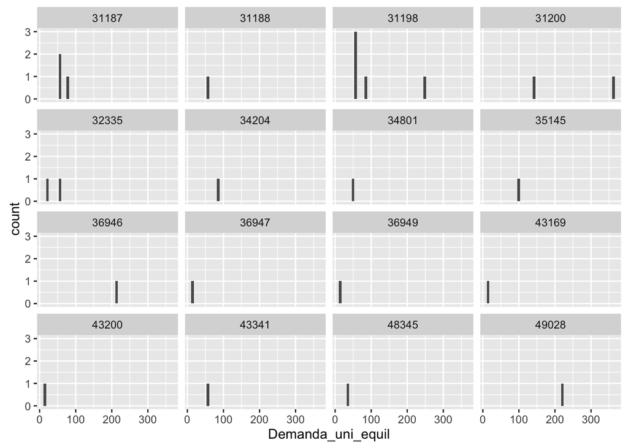

```r
train %>%
    filter(Cliente_ID == clients$Cliente_ID[5]) -> another_client

another_client %>% count(Producto_ID,sort = TRUE) -> products
top_products = products$Producto_ID[1:20]


another_client %>%
    filter(Producto_ID %in% top_products) %>%
    filter(Demanda_uni_equil < 400) %>%
    ggplot(aes(x= Demanda_uni_equil)) +
    geom_histogram(bins = 50) +
    facet_wrap( ~ Producto_ID)
```

This is very interesting, notice the gaps in between the bars. For some of the product ID’s you usually have only certain values it seems - however these are different values for each product. Let’s take a closer look.

Do these trends hold if we look at all clients for the specific product?

```r
train[train$Producto_ID == "31187"] -> a_product

plotly::ggplotly(
qplot(data = filter(a_product, Demanda_uni_equil < 500), x = Demanda_uni_equil, geom = "bar"))
```

[output not shown]

Let’s try another product:

```r
#31198

train[train$Producto_ID == "32335"] -> a_product

plotly::ggplotly(
qplot(data = filter(a_product, Demanda_uni_equil < 500), x = Demanda_uni_equil, geom = "bar"))
```

[output not shown]

The distribution of the demand doesn’t seem to change much from week to week so at least for this client the time dimension of this question doesn’t matter too much.

### let’s now look at how other clients behave with respect to demand:

```r
top_clients = clients$Cliente_ID[2:21]
```

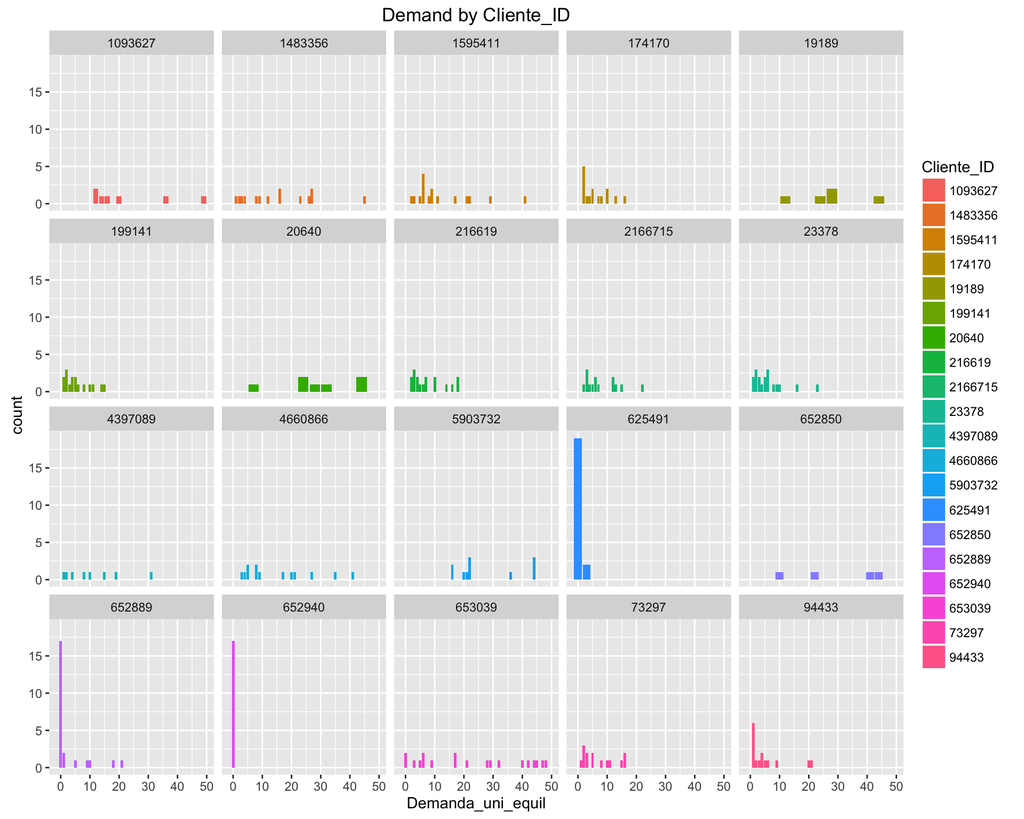

```r
train %>%
    filter(Cliente_ID %in% top_clients) %>%
    plot_it("Cliente_ID", 50) +
    geom_bar(position = "identity") +
    facet_wrap(~ Cliente_ID)
```

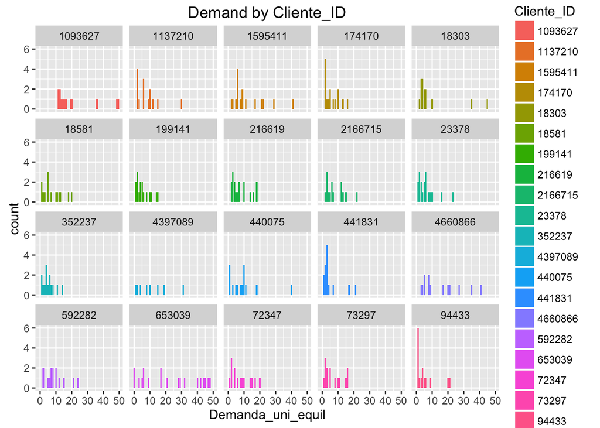

```r
train %>% filter(Demanda_uni_equil > 0, Demanda_uni_equil < 100) %>% count(Cliente_ID, sort = TRUE) -> top_nonzero_clients
top_nonzero_clients = top_nonzero_clients$Cliente_ID[2:21] #the first is too popular

train %>%
    filter(Cliente_ID %in% top_nonzero_clients) %>%
    plot_it("Cliente_ID", 50) +
    geom_bar(position = "identity") +
    facet_wrap(~ Cliente_ID)
```

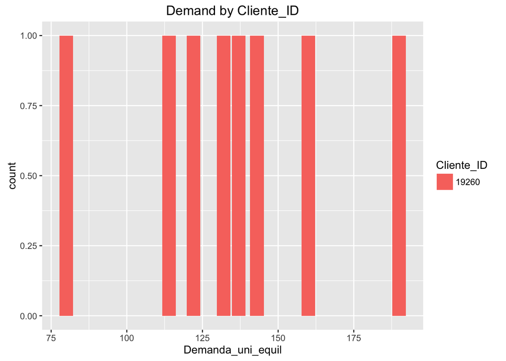

```r
train %>%
    filter(Cliente_ID == "19260") %>%
    plot_it("Cliente_ID", 200) +
    geom_bar(position = "identity")
```

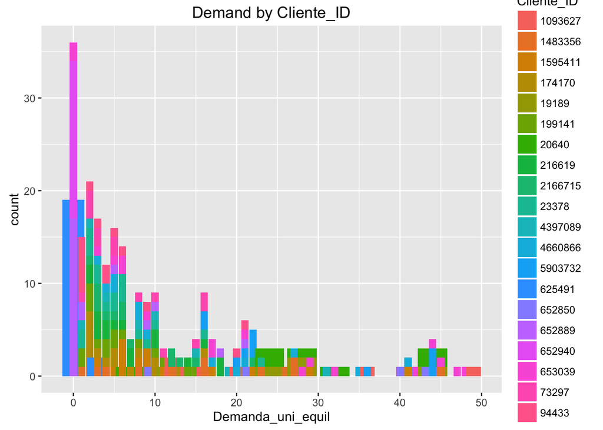

```r
train %>%
    filter(Cliente_ID %in% top_clients) %>%
    plot_it("Cliente_ID", 50) +
    geom_bar()
```

Ok now let’s move on to product_id:

```r
train %>% count(Producto_ID) %>% arrange(desc(n)) -> counts
```

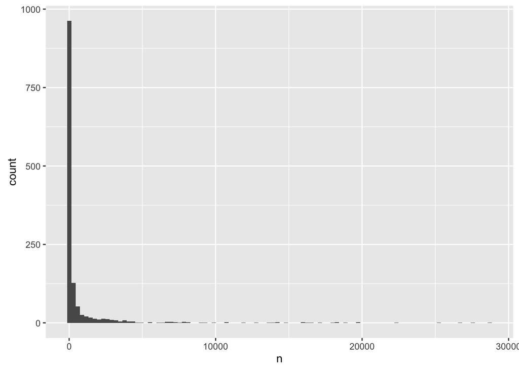

```r
qplot(data = counts, x = n, bins = 100)
```

```r
sum(counts$n[1:200])/sum(counts$n)
```

```
## [1] 0.913525
```

So the most popular 200 product id’s represent around 0.913525 of the data. This is good news since we can decrease the number of factor significatly in our models for `Product_ID`.

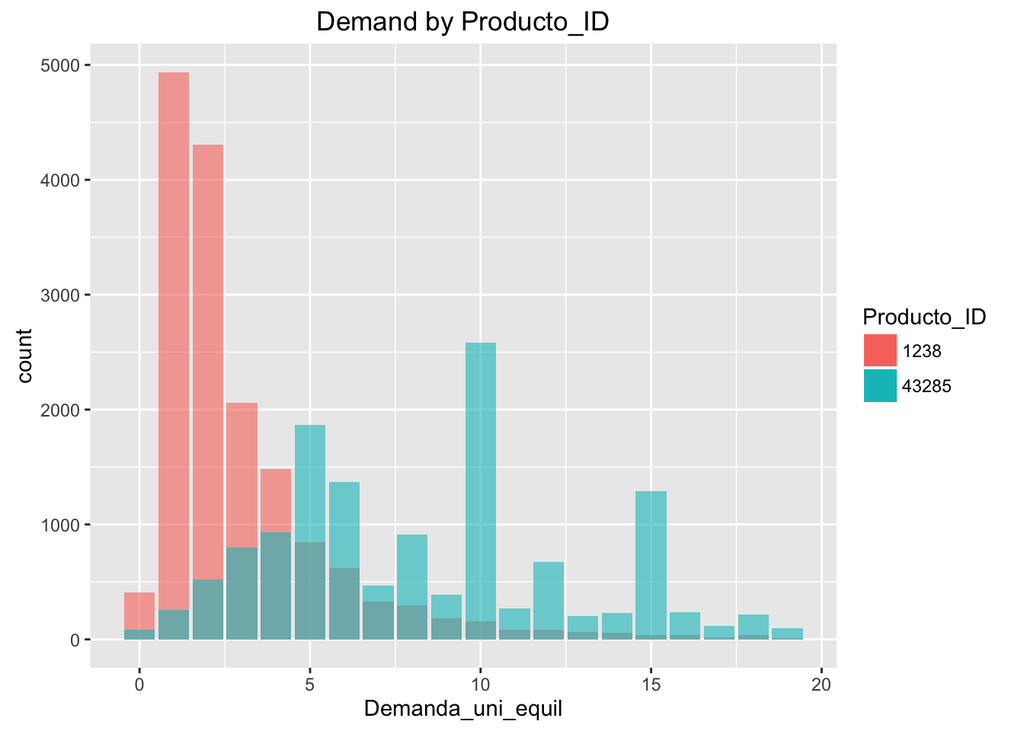

```r
train %>%
    filter(Producto_ID %in% counts$Producto_ID[13:14]) %>%
    plot_it("Producto_ID", 20) +
    geom_bar(position = "identity", alpha = 0.6)
```

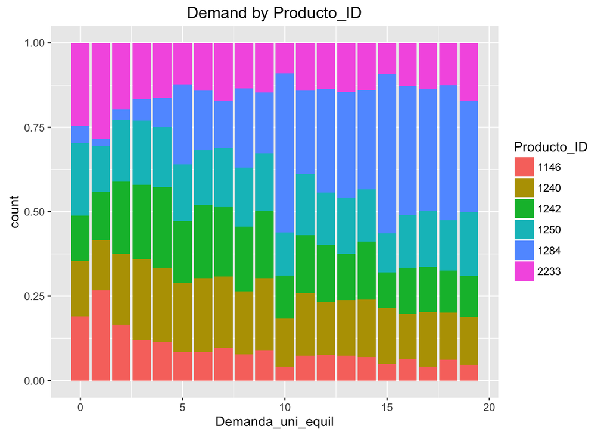

```r
train %>%
    filter(Producto_ID %in% counts$Producto_ID[1:6]) %>%
    plot_it("Producto_ID", 20) +
    geom_bar(position = "fill", alpha = 1)
```

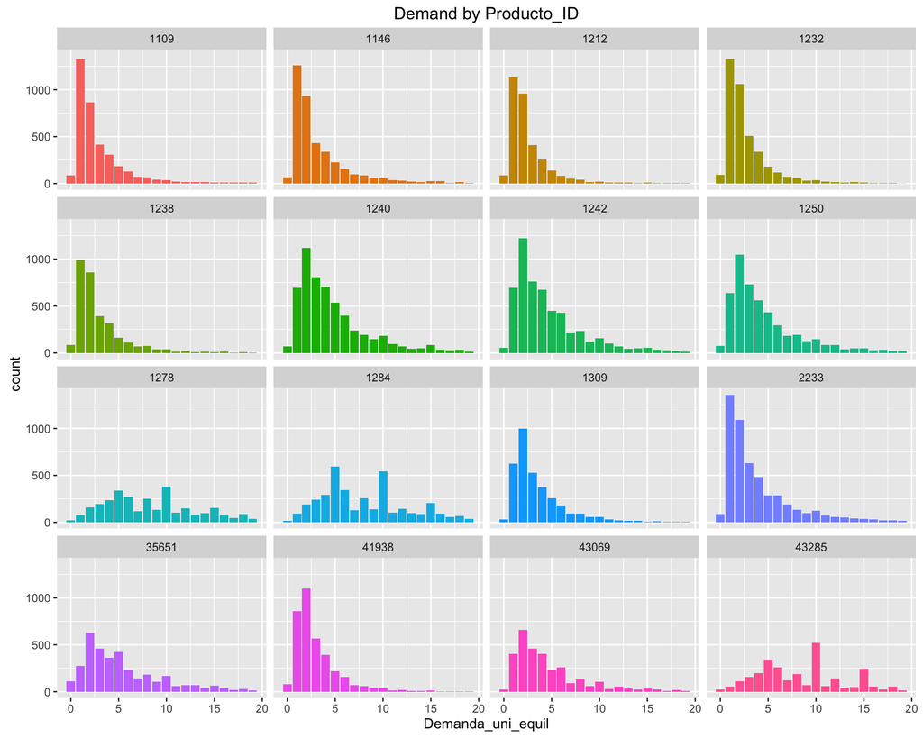

```r
train %>%
    sample_n(size = 2e5) %>% #this takes too long for the entire dataset:
    filter(Producto_ID %in% counts$Producto_ID[1:16]) %>%
    plot_it("Producto_ID", 20) +
    geom_bar() +
    facet_wrap(~ Producto_ID) +
    theme(legend.position = "none")
```

Let’s also take a look at some id’s that are not the most popular:

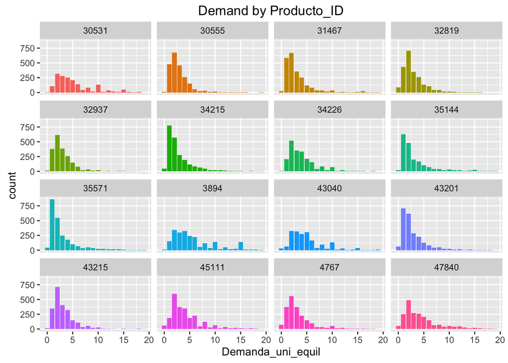

```r
train %>%
    filter(Producto_ID %in% counts$Producto_ID[101:116]) %>%
    plot_it("Producto_ID", 20) +
    geom_bar() +
    facet_wrap(~ Producto_ID) +
    theme(legend.position = "none")
```

And let’s look at some more product ID’s, why not?

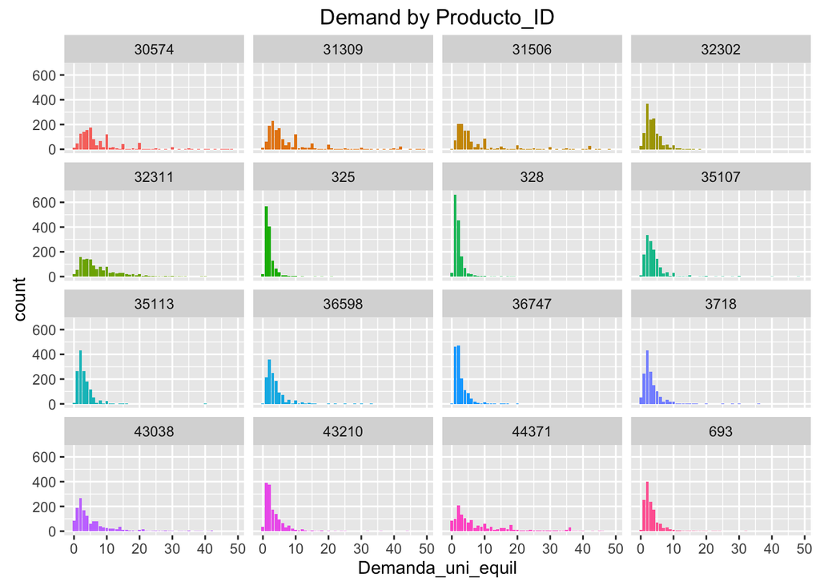

```r
train %>%  #this takes long for the entire dataset:
    filter(Producto_ID %in% counts$Producto_ID[141:156]) -> temp

temp %>%
    plot_it("Producto_ID", 50) +
    geom_bar() +
    facet_wrap(~ Producto_ID) +
    theme(legend.position = "none")
```

After the join we also have a few new features. Let’s look at state:

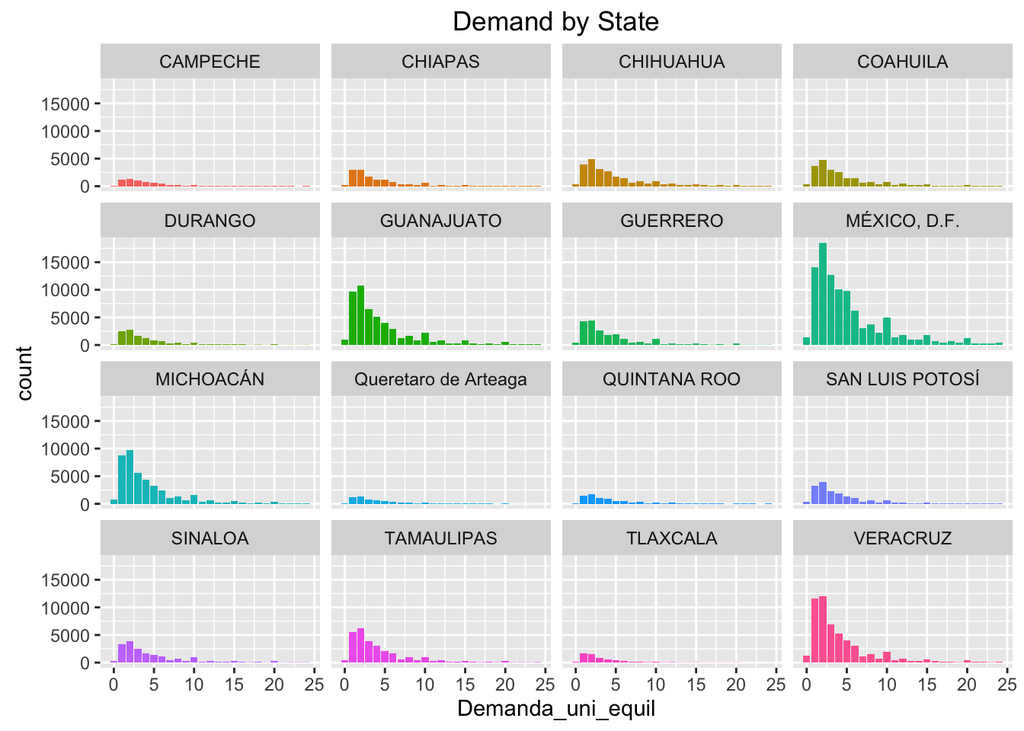

```r
states = unique(train$State)


train[1:1e6] %>%
    filter(State %in% sample(states, 16)) %>%
    plot_it("State") +
    geom_bar() +
    facet_wrap(~ State) +
    theme(legend.position = "none")
```

Still the questions remains: How to see which products have fixed values(multiples of 10, 20 etc.)